```r
library(faraway)
library(ggplot2)
library(lmtest)
```

## Initial Data Analysis

```r
summary(chicago)
```

```
##       race            fire           theft             age
##  Min.   : 1.00   Min.   : 2.00   Min.   :  3.00   Min.   : 2.00
##  1st Qu.: 3.75   1st Qu.: 5.65   1st Qu.: 22.00   1st Qu.:48.60
##  Median :24.50   Median :10.40   Median : 29.00   Median :65.00
##  Mean   :34.99   Mean   :12.28   Mean   : 32.36   Mean   :60.33
##  3rd Qu.:57.65   3rd Qu.:16.05   3rd Qu.: 38.00   3rd Qu.:77.30
##  Max.   :99.70   Max.   :39.70   Max.   :147.00   Max.   :90.10
##      volact         involact          income
##  Min.   : 0.50   Min.   :0.0000   Min.   : 5583
##  1st Qu.: 3.10   1st Qu.:0.0000   1st Qu.: 8447
##  Median : 5.90   Median :0.4000   Median :10694
##  Mean   : 6.53   Mean   :0.6149   Mean   :10696
##  3rd Qu.: 9.65   3rd Qu.:0.9000   3rd Qu.:11989
##  Max.   :14.30   Max.   :2.2000   Max.   :21480
```

Income has much bigger numbers then other parameters. It would have greater weight in the regression model. Hence, to avoid this we standardize the data frame.

## Scaling

```r
ch = chicago
ch$income = ch$income/1000
summary(ch)
```

```
##       race            fire           theft             age
##  Min.   : 1.00   Min.   : 2.00   Min.   :  3.00   Min.   : 2.00
##  1st Qu.: 3.75   1st Qu.: 5.65   1st Qu.: 22.00   1st Qu.:48.60
##  Median :24.50   Median :10.40   Median : 29.00   Median :65.00
##  Mean   :34.99   Mean   :12.28   Mean   : 32.36   Mean   :60.33
##  3rd Qu.:57.65   3rd Qu.:16.05   3rd Qu.: 38.00   3rd Qu.:77.30
##  Max.   :99.70   Max.   :39.70   Max.   :147.00   Max.   :90.10
##      volact         involact          income
##  Min.   : 0.50   Min.   :0.0000   Min.   : 5.583
##  1st Qu.: 3.10   1st Qu.:0.0000   1st Qu.: 8.447
##  Median : 5.90   Median :0.4000   Median :10.694
##  Mean   : 6.53   Mean   :0.6149   Mean   :10.696
##  3rd Qu.: 9.65   3rd Qu.:0.9000   3rd Qu.:11.989
##  Max.   :14.30   Max.   :2.2000   Max.   :21.480
```

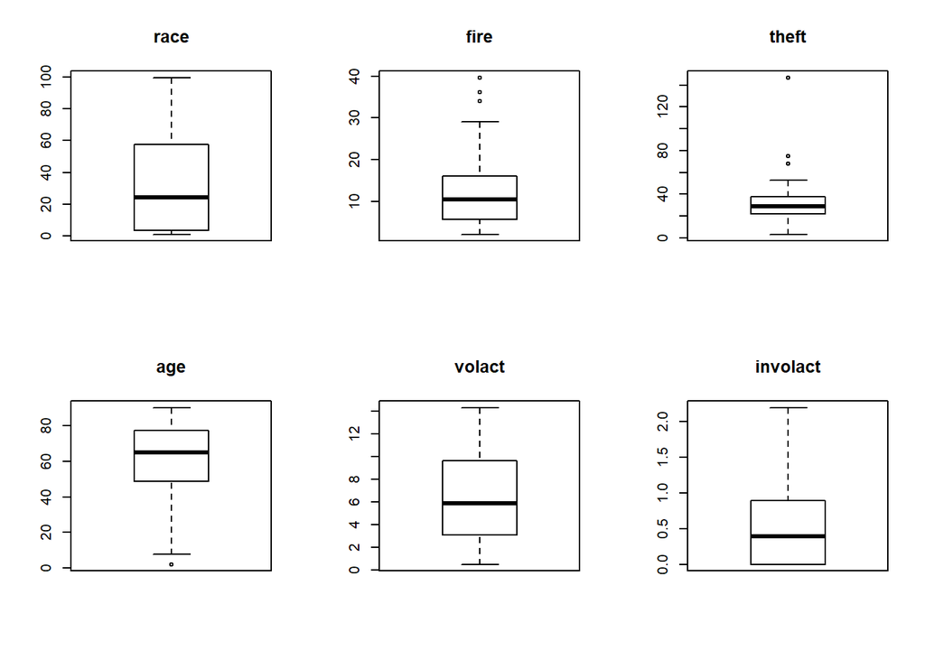

```r
#boxplot(chicago[,7],main=names(chicago)[7])
par(mfrow=c(2,3))
for(i in 1:6)
  boxplot(chicago[,i],main=names(chicago)[i])
```

## Checking the liear Structure of the model

```r
ch= data.frame(ch)
```

```r
lmod_full <- lm(involact~., ch)
lmod_full$rank
```

```
## [1] 7
```

```r
summary(lmod_full)
```

```
##
## Call:
## lm(formula = involact ~ ., data = ch)
##
## Residuals:
##      Min       1Q   Median       3Q      Max
## -0.84296 -0.14613 -0.01007  0.18386  0.81235
##
## Coefficients:
##              Estimate Std. Error t value Pr(>|t|)
## (Intercept) -0.486201   0.602048  -0.808 0.424109
## race         0.008527   0.002863   2.978 0.004911 **
## fire         0.037780   0.008982   4.206 0.000142 ***
## theft       -0.010160   0.002908  -3.494 0.001178 **
## age          0.007615   0.003330   2.287 0.027582 *
## volact      -0.010180   0.027734  -0.367 0.715519
## income       0.025685   0.032199   0.798 0.429759
## ---
## Signif. codes:  0 '***' 0.001 '**' 0.01 '*' 0.05 '.' 0.1 ' ' 1
##
## Residual standard error: 0.3387 on 40 degrees of freedom
## Multiple R-squared:  0.7517, Adjusted R-squared:  0.7144
## F-statistic: 20.18 on 6 and 40 DF,  p-value: 1.072e-10
```

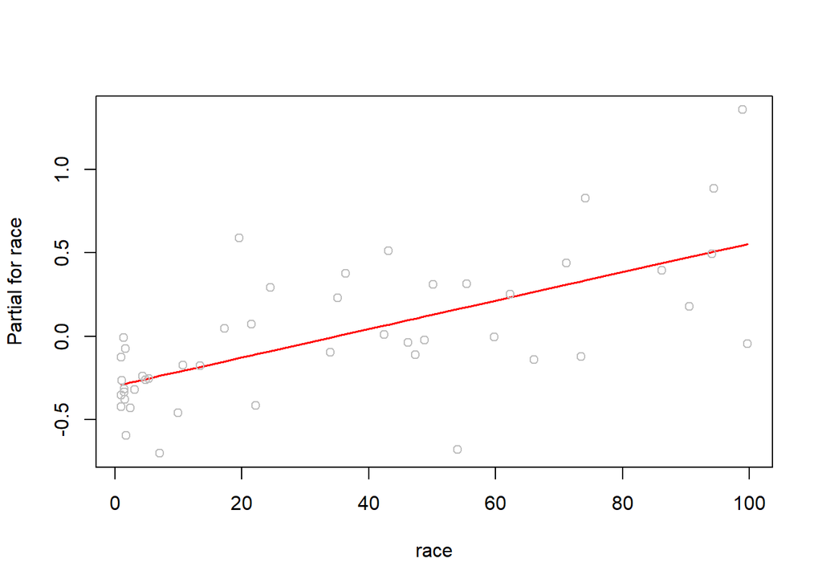

```r
termplot(lmod_full, partial.resid = T, terms=1)
```

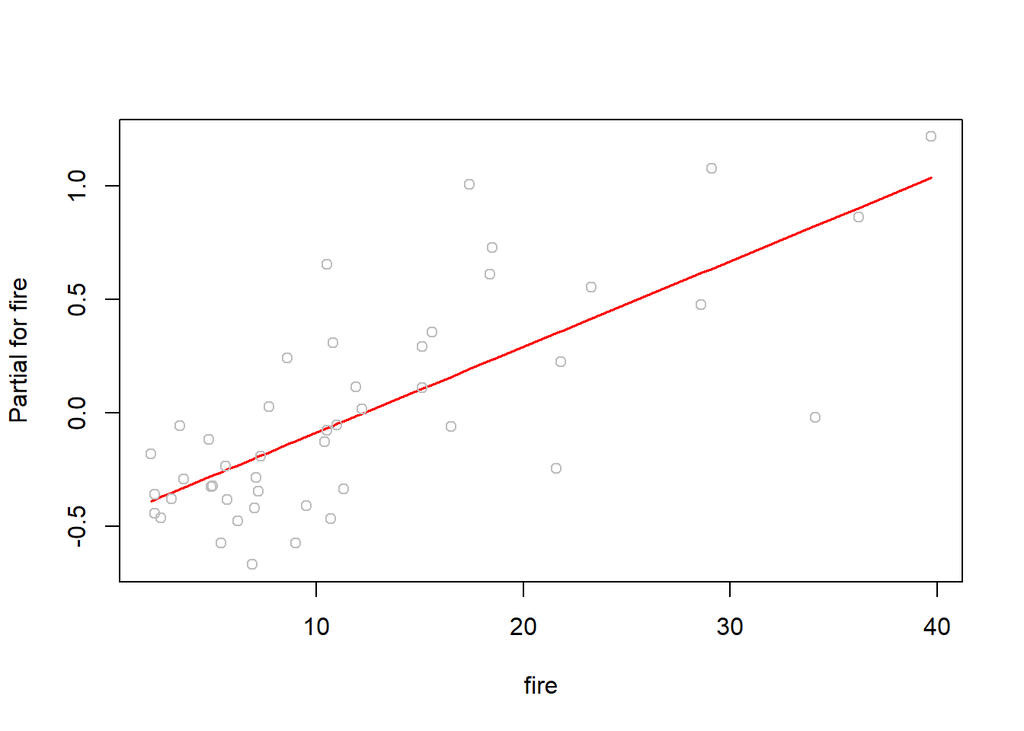

```r
termplot(lmod_full, partial.resid = T, terms=2)
```

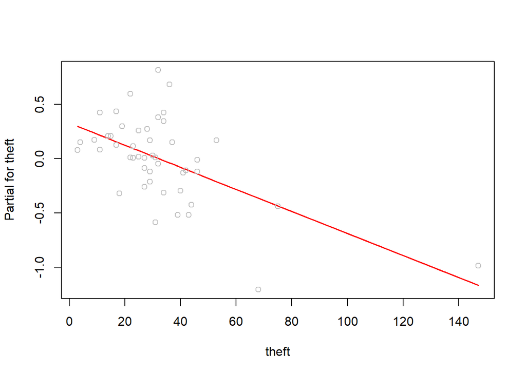

```r
termplot(lmod_full, partial.resid = T, terms=3)
```

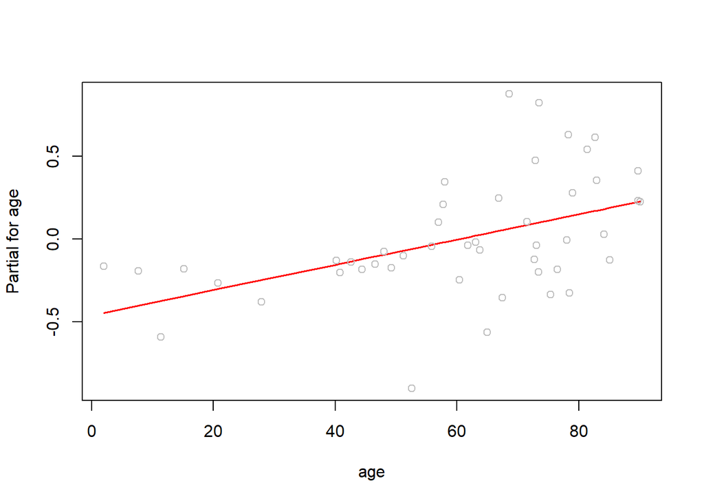

```r
termplot(lmod_full, partial.resid = T, terms=4)
```

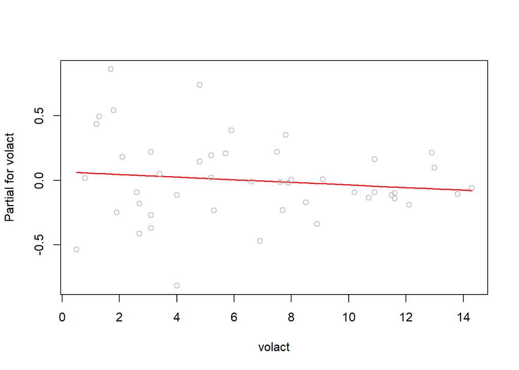

```r
termplot(lmod_full, partial.resid = T, terms=5)
```

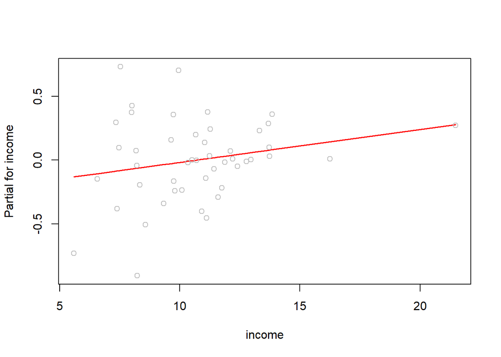

```r
termplot(lmod_full, partial.resid = T, terms=6)
```

Structure Seems Linear

## Checking Normality

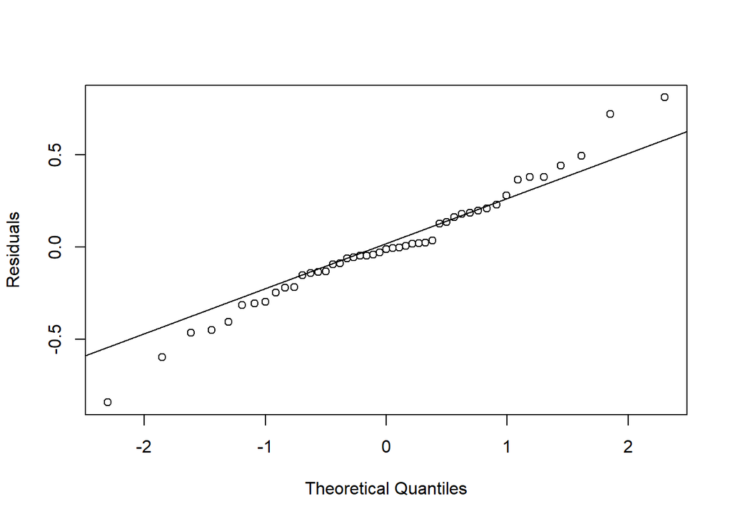

```r
qqnorm(residuals(lmod_full),ylab = "Residuals", main ="")
qqline(residuals(lmod_full))
```

It looks we have fatter tails problem  
Using Shapiro Test for varification.

```r
#Checking using Shapiro Test
  shapiro.test(residuals(lmod_full))
```

```
##
##  Shapiro-Wilk normality test
##
## data:  residuals(lmod_full)
## W = 0.98095, p-value = 0.6317
```

P-value High, Accepting NUll hypotheses. Dist is Normal.

## Checking Error Variance

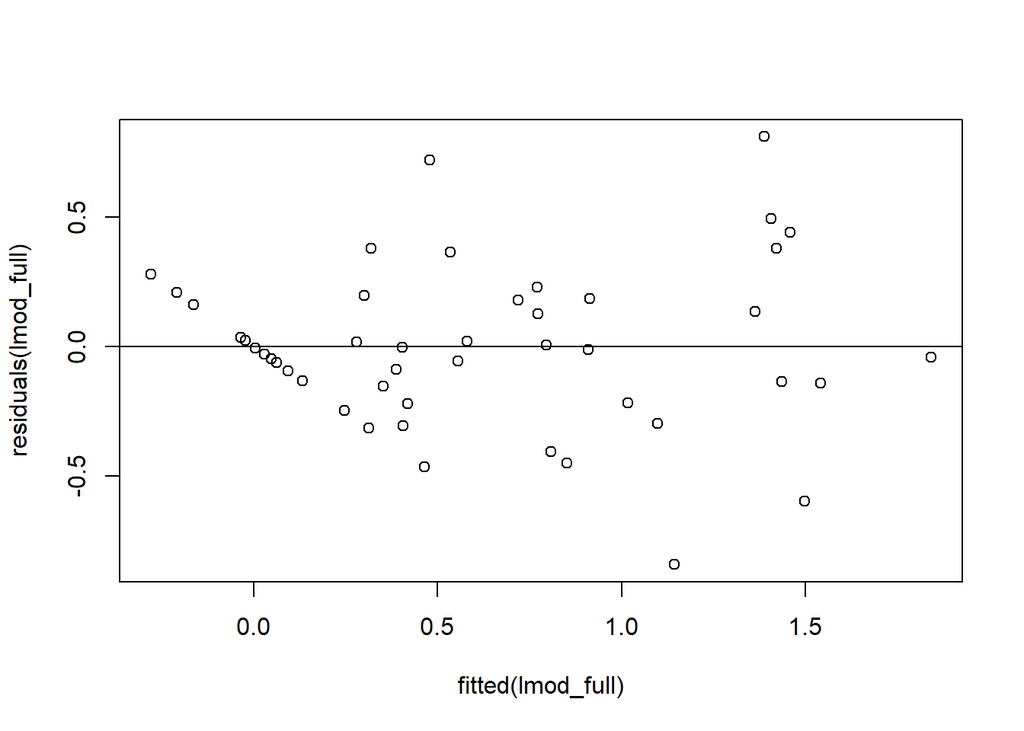

```r
plot(fitted(lmod_full),residuals(lmod_full))
abline(h=0)
```

Looks constant varrience with few anaomles.

## Checking Collinearity

```r
X = model.matrix(lmod_full)[,-1]
cor(X)
```

```
##              race       fire      theft        age     volact     income
## race    1.0000000  0.5927956  0.2550647  0.2505118 -0.7594196 -0.7037328
## fire    0.5927956  1.0000000  0.5562105  0.4122225 -0.6864766 -0.6104481
## theft   0.2550647  0.5562105  1.0000000  0.3176308 -0.3116183 -0.1729226
## age     0.2505118  0.4122225  0.3176308  1.0000000 -0.6057428 -0.5286695
## volact -0.7594196 -0.6864766 -0.3116183 -0.6057428  1.0000000  0.7509780
## income -0.7037328 -0.6104481 -0.1729226 -0.5286695  0.7509780  1.0000000
```

```r
vif(X)
```

```
##     race     fire    theft      age   volact   income
## 3.491088 2.798840 1.684571 2.266203 4.851903 3.153110
```

Every Predictor is under 5. we are safe. (volcat has relatively high correlection with other predictors  
Building model without volact

```r
lmod1_without_volcat = lm(involact ~  race + fire + theft + age + income, ch )
summary(lmod1_without_volcat)
```

```
##
## Call:
## lm(formula = involact ~ race + fire + theft + age + income, data = ch)
##
## Residuals:
##      Min       1Q   Median       3Q      Max
## -0.84428 -0.15804 -0.04093  0.18116  0.80828
##
## Coefficients:
##              Estimate Std. Error t value Pr(>|t|)
## (Intercept) -0.608979   0.495260  -1.230 0.225851
## race         0.009133   0.002316   3.944 0.000307 ***
## fire         0.038817   0.008436   4.602    4e-05 ***
## theft       -0.010298   0.002853  -3.610 0.000827 ***
## age          0.008271   0.002782   2.973 0.004914 **
## income       0.024500   0.031697   0.773 0.443982
## ---
## Signif. codes:  0 '***' 0.001 '**' 0.01 '*' 0.05 '.' 0.1 ' ' 1
##
## Residual standard error: 0.3351 on 41 degrees of freedom
## Multiple R-squared:  0.7508, Adjusted R-squared:  0.7204
## F-statistic: 24.71 on 5 and 41 DF,  p-value: 2.159e-11
```

Model without volcat performs better.  
Now, Checking this using anova.

```r
anova(lmod1_without_volcat,lmod_full)
```

```
## Analysis of Variance Table
##
## Model 1: involact ~ race + fire + theft + age + income
## Model 2: involact ~ race + fire + theft + age + volact + income
##   Res.Df    RSS Df Sum of Sq      F Pr(>F)
## 1     41 4.6047
## 2     40 4.5892  1  0.015457 0.1347 0.7155
```

H0: Beta(r) = 0  
H1: Beta(r) != 0  
High p-value accept Null Hyptoses.  
simpl words: volcat is not significat.  
Cheking Summry of the model

```r
summary(lmod1_without_volcat)
```

```
##
## Call:
## lm(formula = involact ~ race + fire + theft + age + income, data = ch)
##
## Residuals:
##      Min       1Q   Median       3Q      Max
## -0.84428 -0.15804 -0.04093  0.18116  0.80828
##
## Coefficients:
##              Estimate Std. Error t value Pr(>|t|)
## (Intercept) -0.608979   0.495260  -1.230 0.225851
## race         0.009133   0.002316   3.944 0.000307 ***
## fire         0.038817   0.008436   4.602    4e-05 ***
## theft       -0.010298   0.002853  -3.610 0.000827 ***
## age          0.008271   0.002782   2.973 0.004914 **
## income       0.024500   0.031697   0.773 0.443982
## ---
## Signif. codes:  0 '***' 0.001 '**' 0.01 '*' 0.05 '.' 0.1 ' ' 1
##
## Residual standard error: 0.3351 on 41 degrees of freedom
## Multiple R-squared:  0.7508, Adjusted R-squared:  0.7204
## F-statistic: 24.71 on 5 and 41 DF,  p-value: 2.159e-11
```

P-value of income is high. means it insignoficant.  
Lets try removing income.

```r
lmod2_without_volcat_income = lm(involact ~ race + fire + theft + age, ch)
summary(lmod2_without_volcat_income)
```

```
##
## Call:
## lm(formula = involact ~ race + fire + theft + age, data = ch)
##
## Residuals:
##      Min       1Q   Median       3Q      Max
## -0.87108 -0.14830 -0.01961  0.19968  0.81638
##
## Coefficients:
##              Estimate Std. Error t value Pr(>|t|)
## (Intercept) -0.243118   0.145054  -1.676 0.101158
## race         0.008104   0.001886   4.297 0.000100 ***
## fire         0.036646   0.007916   4.629 3.51e-05 ***
## theft       -0.009592   0.002690  -3.566 0.000921 ***
## age          0.007210   0.002408   2.994 0.004595 **
## ---
## Signif. codes:  0 '***' 0.001 '**' 0.01 '*' 0.05 '.' 0.1 ' ' 1
##
## Residual standard error: 0.3335 on 42 degrees of freedom
## Multiple R-squared:  0.7472, Adjusted R-squared:  0.7231
## F-statistic: 31.03 on 4 and 42 DF,  p-value: 4.799e-12
```

Removing it does not make much of the difference  
Comparing 2 model using anova

```r
anova(lmod2_without_volcat_income,lmod1_without_volcat)
```

```
## Analysis of Variance Table
##
## Model 1: involact ~ race + fire + theft + age
## Model 2: involact ~ race + fire + theft + age + income
##   Res.Df    RSS Df Sum of Sq      F Pr(>F)
## 1     42 4.6718
## 2     41 4.6047  1  0.067101 0.5975  0.444
```

H0: Beta(r) = 0  
H1: Beta(r) != 0  
Significane level = 5%  
High p-value accept Null Hyptoses.  
simple words: income is not significat.

## Checking Unusual Observations

### Checking Leverage Points

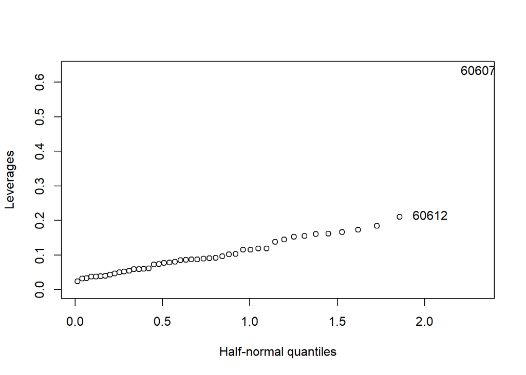

```r
zips = row.names(ch)
hat_vals = hatvalues(lmod2_without_volcat_income)
halfnorm(hat_vals,labs = zips, ylab = "Leverages")
```

Zip Code: 60607 seems to be high leverage points.  
Cheking these observations

```r
row1 = which(rownames(ch) == 60607)
ch[row1,]
```

```
##       race fire theft age volact involact income
## 60607 50.2 39.7   147  83    5.2      0.9  7.459
```

We can observe high theft in this observations  
See what’s happens if we remove this overvations.

```r
lmod3_modified_1 = lm(involact ~ race + fire + theft + age ,ch[-row1])
summary(lmod3_modified_1)
```

```
##
## Call:
## lm(formula = involact ~ race + fire + theft + age, data = ch[-row1])
##
## Residuals:
##      Min       1Q   Median       3Q      Max
## -0.87108 -0.14830 -0.01961  0.19968  0.81638
##
## Coefficients:
##              Estimate Std. Error t value Pr(>|t|)
## (Intercept) -0.243118   0.145054  -1.676 0.101158
## race         0.008104   0.001886   4.297 0.000100 ***
## fire         0.036646   0.007916   4.629 3.51e-05 ***
## theft       -0.009592   0.002690  -3.566 0.000921 ***
## age          0.007210   0.002408   2.994 0.004595 **
## ---
## Signif. codes:  0 '***' 0.001 '**' 0.01 '*' 0.05 '.' 0.1 ' ' 1
##
## Residual standard error: 0.3335 on 42 degrees of freedom
## Multiple R-squared:  0.7472, Adjusted R-squared:  0.7231
## F-statistic: 31.03 on 4 and 42 DF,  p-value: 4.799e-12
```

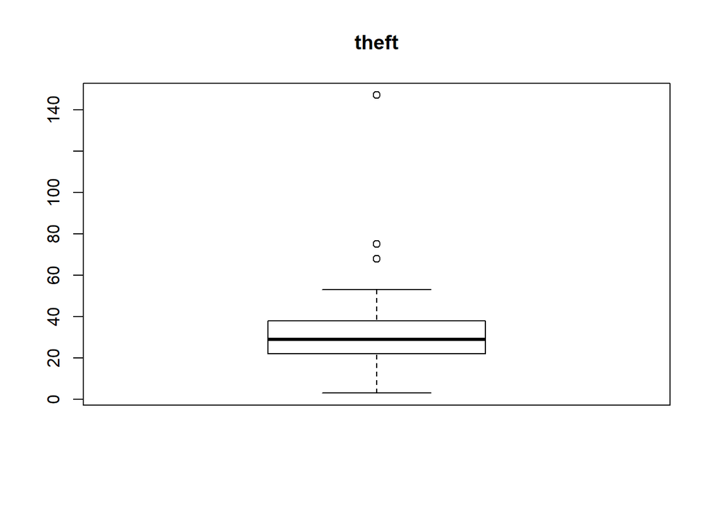

```r
theft = 3
boxplot(ch[,theft],main=names(ch)[theft])
```

This observation theft value is far higer then other observation. it must be reported.

## Checking Outliers

```r
sort(abs(residuals(lmod2_without_volcat_income)))
```

```
##       60631       60619       60632       60616       60638       60618
## 0.001966931 0.004373166 0.007351602 0.013648913 0.018400932 0.019607322
##       60651       60643       60645       60612       60646       60635
## 0.021481962 0.036764563 0.038561267 0.043673115 0.069513114 0.079401224
##       60634       60629       60607       60636       60630       60609
## 0.085058456 0.090890292 0.093118206 0.104531778 0.110429605 0.118843923
##       60633       60655       60608       60620       60639       60644
## 0.126700197 0.131776158 0.148096306 0.160332787 0.169898411 0.186612598
##       60657       60656       60647       60611       60626       60628
## 0.193319018 0.206048996 0.207880464 0.212589033 0.222429899 0.238847285
##       60627       60652       60637       60640       60641       60614
## 0.250934003 0.255827264 0.308243446 0.314421019 0.323936345 0.350925819
##       60649       60617       60624       60615       60622       60625
## 0.358846125 0.360328508 0.385193257 0.451842984 0.457316717 0.460601200
##       60623       60653       60613       60621       60610
## 0.510361779 0.627657515 0.714891996 0.816376747 0.871077427
```

```r
#Getting Outlier Rows
rn = rownames(ch)
rows_outliers = subset(ch, rn == 60610 | rn == 60621 | rn == 60613 | rn == 60653)
rows_outliers
```

```
##       race fire theft  age volact involact income
## 60613 19.6 10.5    36 73.5    4.8      1.2  9.948
## 60610 54.0 34.1    68 52.6    4.0      0.3  8.231
## 60653 99.7 21.6    31 65.0    0.5      0.9  5.583
## 60621 98.9 17.4    32 68.6    1.7      2.2  7.520
```

```r
#buliding model with out them
lmod2_without_volcat_income_outlier_removed = lm(involact ~ race + fire + theft + age, data = ch[-c(60653,60613,60621,60610),])
summary(lmod2_without_volcat_income)
```

```
##
## Call:
## lm(formula = involact ~ race + fire + theft + age, data = ch)
##
## Residuals:
##      Min       1Q   Median       3Q      Max
## -0.87108 -0.14830 -0.01961  0.19968  0.81638
##
## Coefficients:
##              Estimate Std. Error t value Pr(>|t|)
## (Intercept) -0.243118   0.145054  -1.676 0.101158
## race         0.008104   0.001886   4.297 0.000100 ***
## fire         0.036646   0.007916   4.629 3.51e-05 ***
## theft       -0.009592   0.002690  -3.566 0.000921 ***
## age          0.007210   0.002408   2.994 0.004595 **
## ---
## Signif. codes:  0 '***' 0.001 '**' 0.01 '*' 0.05 '.' 0.1 ' ' 1
##
## Residual standard error: 0.3335 on 42 degrees of freedom
## Multiple R-squared:  0.7472, Adjusted R-squared:  0.7231
## F-statistic: 31.03 on 4 and 42 DF,  p-value: 4.799e-12
```

```r
summary(lmod2_without_volcat_income_outlier_removed)
```

```
##
## Call:
## lm(formula = involact ~ race + fire + theft + age, data = ch[-c(60653,
##     60613, 60621, 60610), ])
##
## Residuals:
##      Min       1Q   Median       3Q      Max
## -0.87108 -0.14830 -0.01961  0.19968  0.81638
##
## Coefficients:
##              Estimate Std. Error t value Pr(>|t|)
## (Intercept) -0.243118   0.145054  -1.676 0.101158
## race         0.008104   0.001886   4.297 0.000100 ***
## fire         0.036646   0.007916   4.629 3.51e-05 ***
## theft       -0.009592   0.002690  -3.566 0.000921 ***
## age          0.007210   0.002408   2.994 0.004595 **
## ---
## Signif. codes:  0 '***' 0.001 '**' 0.01 '*' 0.05 '.' 0.1 ' ' 1
##
## Residual standard error: 0.3335 on 42 degrees of freedom
## Multiple R-squared:  0.7472, Adjusted R-squared:  0.7231
## F-statistic: 31.03 on 4 and 42 DF,  p-value: 4.799e-12
```

## Checking Influencial Observations

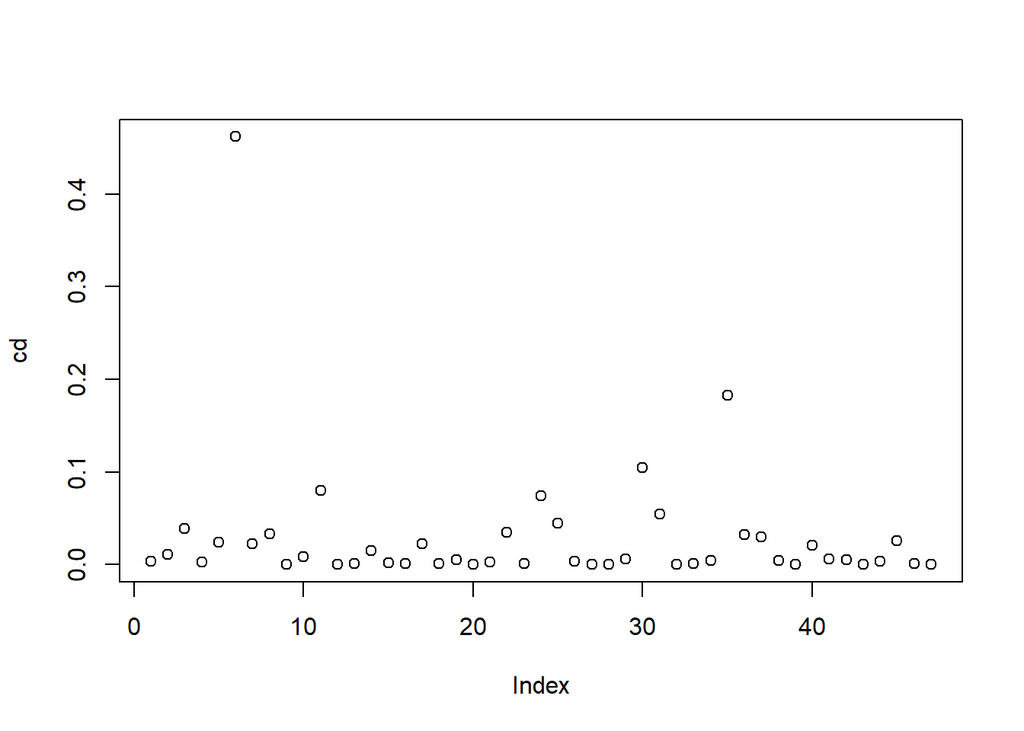

```r
cd = cooks.distance(lmod2_without_volcat_income)
plot(cd)
abline(h=0.5)
```

2nd method

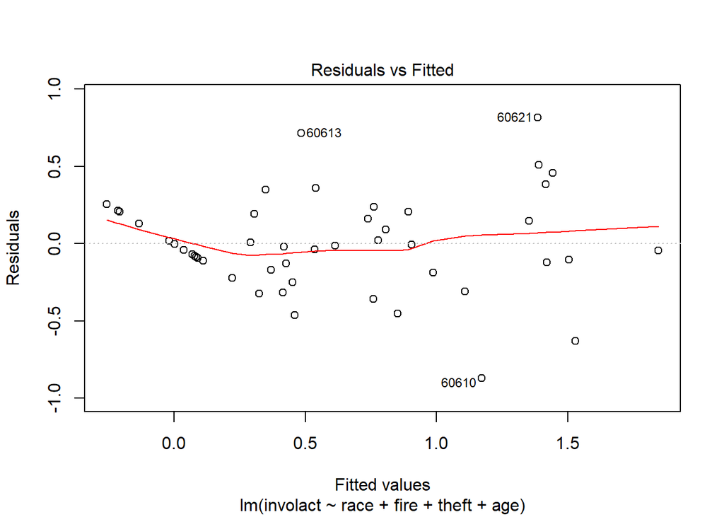

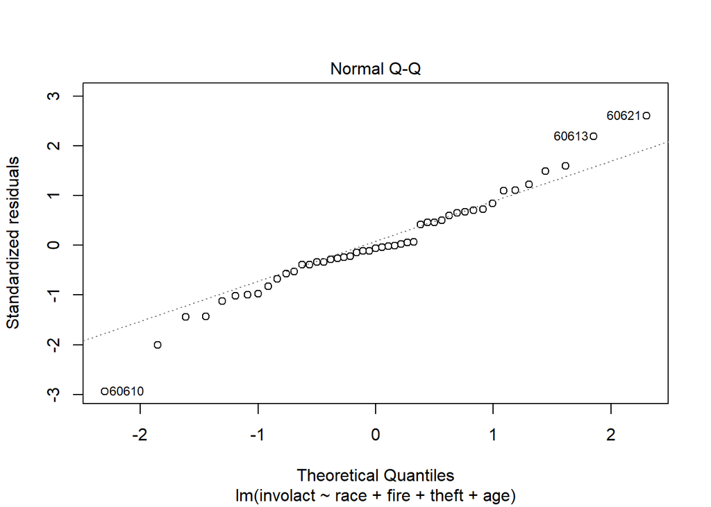

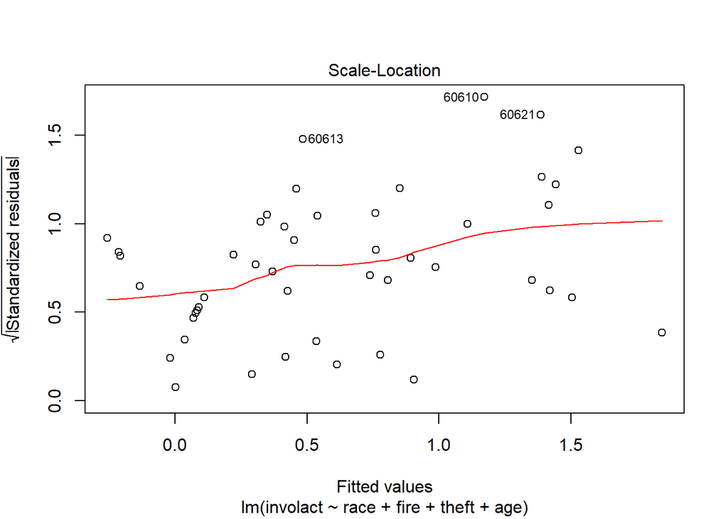

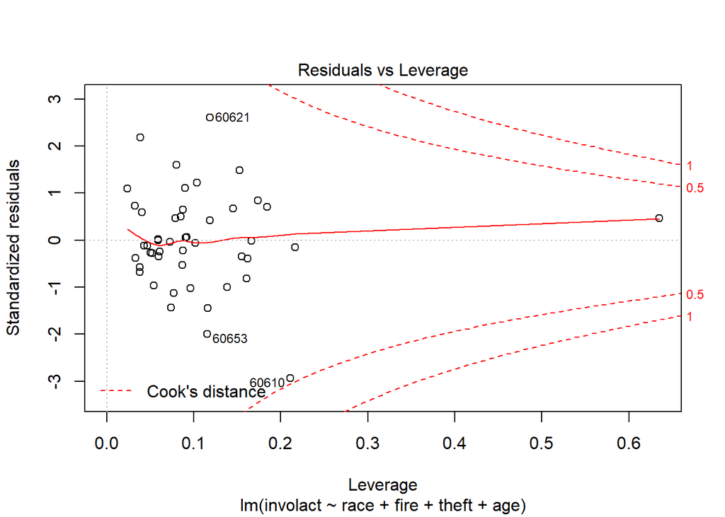

```r
plot(lmod2_without_volcat_income)
```